# rOpenSci: Como acceder de forma reproducible a repositorios de datos publicos

I. Bartomeus

14/02/2017

El uso de datos publicos ha abierto la puerta a responder un abanico de preguntas que antes era inimaginable. En ecologia hay repositorios de datos de occurrencia de especies (www.gbif.com), climaticos (www.worldclim.com) o filogeneticos (www.treebase.com) que por si solos o combinados permiten analisis para testar teorias generales a una escala global. Sin embargo, obtener estos datos suele hacerse de forma no reproducible mediante el uso de interficies web. Estas interficies son utiles para explorar los datos y te permiten seleccionar que tipo de datos quieres y descargarlos a tu ordenador, pero en este proceso es suboptimo por dos razones. Primero, una vez tienes los datos, es imposible recordar que selección hizistes exactamente (no hay trazabilidad). Segundo, cuando hay nuevos datos disponibles o se han corregido errores en los datos originales del repositorio es imposible actualizar tus datos de forma automatica.

El equipo de @ropensci, entre otras cosas, se dedica a crear paquetes de R que permiten el acceso a datos publicos desde tu terminal de R. Esto te permite tener un codigo que es legible tanto por maquinas, como por humanos que especifica exactamante que datos has descargado (hay una trazabilidad completa). Asimismo, actualizar los datos con los ultimos cambios no requiere más esfuerzo que volver a correr el codigo. Las ventajas no son solo en incrementar la reproducibilidad de tus resultados, sino sobretodo te permite ahorrar tiempo y reducir el numero de pasos, y por siguiente el numero de potenciales errores de bulto que se pueden cometer en cada paso, de tu flujo de trabajo.

1. Instalar y cargar el paquete

```r
#install.packages("rgbif") #solo has de instalarlo la primera vez
library(rgbif)
```

2. Bajar los datos que queremos

```r
dat <- occ_search(scientificName = "Andrena flavipes", limit = 50)
dat
```

```
## Records found [4002]
## Records returned [50]
## No. unique hierarchies [1]
## No. media records [20]
## No. facets [0]
## Args [scientificName=Andrena flavipes, limit=50, offset=0, fields=all]
## # A tibble: 50 × 69
##                name        key decimalLatitude decimalLongitude
##               <chr>      <int>           <dbl>            <dbl>
## 1  Andrena flavipes 1338054317        52.43417          9.69895
## 2  Andrena flavipes 1337986417        50.38213          8.75469
## 3  Andrena flavipes 1337947699        50.17731          8.54668
## 4  Andrena flavipes 1338031614        51.55624          9.95618
## 5  Andrena flavipes 1431673304        55.94490         12.77240
## 6  Andrena flavipes 1430035601        55.37960         13.07760
## 7  Andrena flavipes 1338035142        51.06245         13.70485
## 8  Andrena flavipes 1430044735        55.38330         14.06260
## 9  Andrena flavipes 1338059217        50.07270          9.04534
## 10 Andrena flavipes 1338102832        52.00281          9.86017
## # ... with 40 more rows, and 65 more variables: issues <chr>,
## #   datasetKey <chr>, publishingOrgKey <chr>, publishingCountry <chr>,
## #   protocol <chr>, lastCrawled <chr>, lastParsed <chr>, crawlId <int>,
## #   extensions <chr>, basisOfRecord <chr>, taxonKey <int>,
## #   kingdomKey <int>, phylumKey <int>, classKey <int>, orderKey <int>,
## #   familyKey <int>, genusKey <int>, speciesKey <int>,
## #   scientificName <chr>, kingdom <chr>, phylum <chr>, order <chr>,
## #   family <chr>, genus <chr>, species <chr>, genericName <chr>,
## #   specificEpithet <chr>, taxonRank <chr>,
## #   coordinateUncertaintyInMeters <dbl>, year <int>, month <int>,
## #   day <int>, eventDate <chr>, lastInterpreted <chr>, license <chr>,
## #   identifiers <chr>, facts <chr>, relations <chr>, geodeticDatum <chr>,
## #   class <chr>, countryCode <chr>, country <chr>, recordedBy <chr>,
## #   catalogNumber <chr>, institutionCode <chr>, locality <chr>,
## #   collectionCode <chr>, gbifID <chr>, individualCount <int>,
## #   coordinatePrecision <dbl>, elevation <dbl>, elevationAccuracy <dbl>,
## #   depth <dbl>, depthAccuracy <dbl>, stateProvince <chr>, modified <chr>,
## #   identifier <chr>, county <chr>, occurrenceID <chr>,
## #   identifiedBy <chr>, eventID <chr>, occurrenceStatus <chr>,
## #   fieldNumber <chr>, datasetID <chr>, type <chr>
```

3. Plotear los datos obtenidos.

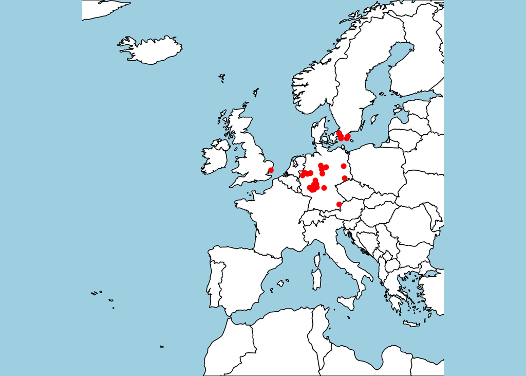

```r
library(maps)
map("world", fill=TRUE, col="white", bg="lightblue", ylim=c(30, 70), xlim = c(-30,30), mar=c(0,0,0,0))
points(dat$data$decimalLongitude, dat$data$decimalLatitude, col="red", pch=16)
```